# Spatial Autocorrelation

Albert Y. Kim  
Friday 2015/03/20

### First Law of Geography

Geographer and statistician Waldo Tobler (1970) summarized a key component affecting any analysis of spatially referenced data through his **first law of geography**:

*Everything is related to everything else, but near things are more related than far things.*

### Spatial Autocorrelation

This succinctly defines the statistical notion of **(positive) spatial autocorrelation**, in which pairs of observations taken nearby are more alike than those taken farther apart. i.e. they are correlated.

Such data violate the **independence assumption** that many standard statistical methods hinge on and therefore spatial autocorrelation must be accounted for.

### Spatial Autocorrelation

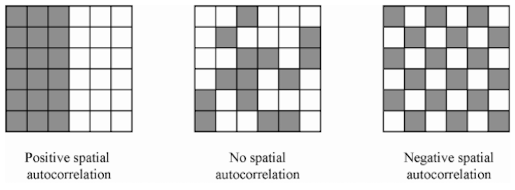

### Map of Multnomah County

Consider a map of the 171 regions (i.e. census tracts) in Multnomah county. For each region we mark its **geographic centroid**

- i.e. its 2-dimensional mean
- i.e. the point at which if you held it by a needle underneath, the region would balance

### Map of Multnomah County

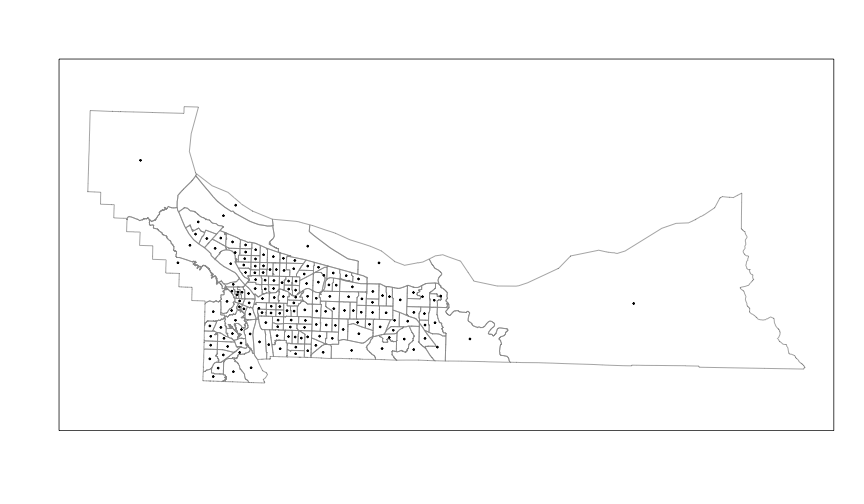

### Map of Multnomah County

There are:

- 882 total links i.e. pairs of regions that share a border
- Distribution of the number of links. Ex: There are 11 regions that have 3 neighbors.

```
 3  4  5  6  7  8  9 10 11
11 45 62 31 12  6  1  1  2
```

### Spatial Connectivity

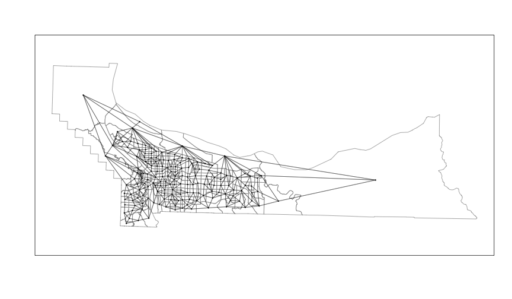

### Spatial Autocorrelation

A **global index of spatial autocorrelation** provides a summary over the entire study area of the level of spatial similarity observed among neighboring observations.

Say we have \( n \) regions each with a measurement of some variable of interest \( Y_i \) for \( i=1, \ldots, n \)

Today we'll investigate \( Y_i \) = proportion of the \( n=171 \) census tract's population that are hispanic.

### Global Indices of Spatial Autocorrelation

Let

- \( w_{ij} \) be a weight describing the proximity of regions \( i \) and \( j \)
- \( \mbox{sim}_{ij} \) be a measure of similarity between \( Y_i \) and \( Y_j \)

Most global indices are of the form:

\[ \frac{\sum_{i=1}^{n}\sum_{j=1}^{n}w_{ij} \mbox{sim}_{ij}}{\sum_{i=1}^{n}\sum_{j=1}^{n}w_{ij}} \]

i.e. it's a weighted average of the similarity of the variable over all pairs of regions.

### Moran's I

Moran's \( I \) statistic (1950) is among the most used measures

\[ \frac{1}{s^2}\frac{\sum_{i=1}^{n}\sum_{j=1}^{n}w_{ij} (Y_i - \overline{Y})(Y_j - \overline{Y})}{\sum_{i=1}^{n}\sum_{j=1}^{n}w_{ij}} \] where \[ s^2 = \frac{1}{N} \sum_{i=1}^{N} (Y_i - \overline{Y})^2 \]

This is used as hypothesis test statistic.

### Properties of Moran's I

- If neighboring regions tend to
  - have similar values (pattern is clustered): \( I \) will be positive
  - have different values (pattern is regular): \( I \) will be negative
- Under the null hypothesis of no spatial correlation, the expected value of \( I \) is \[ -\frac{1}{N-1} \]
- Unlike a traditional correlation coefficient, \( I \) is not restricted to be between \( [-1,1] \)
- A \( p \)-value is computed.

### Today's Example

You're going to evaluate Moran's \( I \) assuming proximity weights

\[ w_{ij} = \left\{ \begin{array}{cl} 1 & \mbox{if regions $i$ and $j$ share a border}\\ & \mbox{(not including corners)}\\ 0 & \mbox{otherwise} \end{array} \right. \]

to see if Hispanic populations in Mulnomah County tend to **cluster** i.e. exhibit positive spatial autocorreleation.

### Legislative Branch of the US Government

Bicameral legislature:

1. House of Representatives
2. Senate

### House of Representatives

Seats are distributed proportionally to population size. After the 2010 Census the changes were:

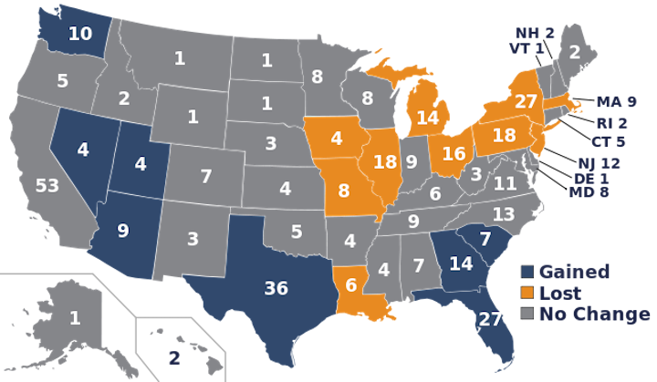

### Senate

Two seats per state.